# Problem 3

**a.i)** Using the expression for $p_i$ one obtains the following expression using the log-odds function

$$\text{logit}(p_i)=\log(\frac{p_i}{1-p_i}) = \log(p_i)-\log(1-p_i) = \log(\frac{e^{\beta_0+\mathbf{x}^T\boldsymbol{\beta}}}{1+e^{\beta_0+\mathbf{x}^T\boldsymbol{\beta}}}) - \log(1-\frac{e^{\beta_0+\mathbf{x}^T\boldsymbol{\beta}}}{1+e^{\beta_0+\mathbf{x}^T\boldsymbol{\beta}}})$$
This expression can be further simplified as
$$\text{logit}(p_i)=\log(e^{\beta_0+\mathbf{x}^T\boldsymbol{\beta}})-\log(1+e^{\beta_0+\mathbf{x}^T\boldsymbol{\beta}}) - \log(\frac{1+e^{\beta_0+\mathbf{x}^T\boldsymbol{\beta}}-e^{\beta_0+\mathbf{x}^T\boldsymbol{\beta}}}{1+e^{\beta_0+\mathbf{x}^T\boldsymbol{\beta}}})= \beta_0+\mathbf{x}^T\boldsymbol{\beta} - \log(1+e^{\beta_0+\mathbf{x}^T\boldsymbol{\beta}}) - \log(\frac{1}{1+e^{\beta_0+\mathbf{x}^T\boldsymbol{\beta}}}).$$
And so, the expression becomes
$$\text{logit}(p_i)=\beta_0+\mathbf{x}^T\boldsymbol{\beta}-\log(1+e^{\beta_0+\mathbf{x}^T\boldsymbol{\beta}})-\log(1)+\log(1+e^{\beta_0+\mathbf{x}^T\boldsymbol{\beta}})=\beta_0+\mathbf{x}^T\boldsymbol{\beta}.$$
Which indeed shows that the log-odds function is a linear function of the covariates.

**ii)** To find the parameters for the logistic regression method, the following code was used

```r
#Estimate parameters
diabetes.glm = glm(diabetes ~., data = train, family="binomial")
summary(diabetes.glm)
```

```
##
## Call:
## glm(formula = diabetes ~ ., family = "binomial", data = train)
##
## Deviance Residuals:
##     Min       1Q   Median       3Q      Max
## -2.8155  -0.6367  -0.3211   0.6147   2.2408
##
## Coefficients:
##               Estimate Std. Error z value Pr(>|z|)
## (Intercept) -10.583538   1.428276  -7.410 1.26e-13 ***
## npreg         0.105109   0.062721   1.676 0.093775 .
## glu           0.035586   0.005892   6.039 1.55e-09 ***
## bp           -0.014654   0.013982  -1.048 0.294615
## skin          0.020379   0.020575   0.990 0.321962
## bmi           0.094683   0.031265   3.028 0.002458 **
## ped           1.931666   0.529573   3.648 0.000265 ***
## age           0.038291   0.020247   1.891 0.058594 .
## ---
## Signif. codes:  0 '***' 0.001 '**' 0.01 '*' 0.05 '.' 0.1 ' ' 1
##
## (Dispersion parameter for binomial family taken to be 1)
##
##     Null deviance: 381.91  on 299  degrees of freedom
## Residual deviance: 253.84  on 292  degrees of freedom
## AIC: 269.84
##
## Number of Fisher Scoring iterations: 5
```

Here, one can see the parameter values for the corresponding predictors. Now that the model has been trained, it can be used to predict the response from the testing set of predictors, and compare it to the actual response in a confusion matrix. To do this, the following code was used

```r
#Logisitc regression, predict response using the model.
glm.results = predict(diabetes.glm,newdata= test,type="response") #Returns probability of having diabetes
#Make a table with predictions and true values. Make confusion matrix
response = ifelse(test$diabetes==1,"Diabetic", "Non-diabetic") #Changes from 1/0 to diabetes/not-biabetes
glm.pred = ifelse(round(glm.results,0)==1,"Diabetic", "Non-diabetic") #save the results with new labels. Cuts off at 0.5 with round()

#Make confusion table
tab = table("Predicted" = glm.pred, "Response" = response) #Using round to simulate 0.5 cutoff
confmat = confusionMatrix(tab,positive="Diabetic") #For calculating specificity and sensitivity
confmat #Show the results
```

```
## Confusion Matrix and Statistics
##
##               Response
## Predicted      Diabetic Non-diabetic
##   Diabetic           48           18
##   Non-diabetic       29          137
##
##                Accuracy : 0.7974
##                  95% CI : (0.7399, 0.8472)
##     No Information Rate : 0.6681
##     P-Value [Acc > NIR] : 9.374e-06
##
##                   Kappa : 0.5262
##
##  Mcnemar's Test P-Value : 0.1447
##
##             Sensitivity : 0.6234
##             Specificity : 0.8839
##          Pos Pred Value : 0.7273
##          Neg Pred Value : 0.8253
##              Prevalence : 0.3319
##          Detection Rate : 0.2069
##    Detection Prevalence : 0.2845
##       Balanced Accuracy : 0.7536
##
##        'Positive' Class : Diabetic
##
```

Thus, one sees that the sensitivity of the model is 0.6233766, and the specificity is 0.883871.

**b.i)** $\pi_k$ is the fraction of a population that belong to class $k$. It can be interpreted as the probability of being in class $k$ with no knowledge of the predictors. Thus $\pi_0$ will be the fraction of people whom does not have diabetes, and $\pi_1$ is the fraction of people whom have diabetes. In the model, $\pi_k$ is estimated by taking the fraction of observations classified to class $k$ divided by the number of observations.

$\boldsymbol{\mu}_k$ is the vector of expected values of the predictors for observations that belong to class $k$. Thus, $\boldsymbol{\mu}_0$ is the vector containing the expected values for bmi, age, glu etc among the non-diabetic participants. Then, $\boldsymbol{\mu}_1$ is the vector containing the excpected values for diabetic participants. In the model $\boldsymbol{\mu}_k$ is estimated by taking the mean over each value for each class.

$\boldsymbol{\Sigma}$ is the covariance matrix of the predictors. It is assumed, through lda, that $\boldsymbol{\Sigma}_k$ will be the same regardless of the class. The matrix stores the variance for the different predictors. In this case these will be the variances in bmi, age, glu etc.  
$f_k(x)$ is the probability density function for class $k$. Since the different classes usually have different expected-values, the response for each class will be distributed differently. This is a key point as it is used in posterior analysis to determine which class the observed set of predictors most likely belong to.  
**ii)** Here the models are fitted and the confusion tables created. The standard cut-off for these functions are at 0.5, so it does not have to be done manually.

```r
#LDA, estimate parameters
diabetes.lda = lda(diabetes ~., data = train, type = "response") #train model
lda.results= predict(diabetes.lda, test) #Predict with 0.5 cutoff
lda.pred = ifelse(lda.results$class==1,"Diabetic", "Non-diabetic")

#Make confusion matrix for LDA
confmatlin = confusionMatrix(table("Predicted"=lda.pred, "Response"=response), positive="Diabetic")
confmatlin #Display
```

```
## Confusion Matrix and Statistics
##
##               Response
## Predicted      Diabetic Non-diabetic
##   Diabetic           47           17
##   Non-diabetic       30          138
##
##                Accuracy : 0.7974
##                  95% CI : (0.7399, 0.8472)
##     No Information Rate : 0.6681
##     P-Value [Acc > NIR] : 9.374e-06
##
##                   Kappa : 0.5229
##
##  Mcnemar's Test P-Value : 0.08005
##
##             Sensitivity : 0.6104
##             Specificity : 0.8903
##          Pos Pred Value : 0.7344
##          Neg Pred Value : 0.8214
##              Prevalence : 0.3319
##          Detection Rate : 0.2026
##    Detection Prevalence : 0.2759
##       Balanced Accuracy : 0.7504
##
##        'Positive' Class : Diabetic
##
```

```r
#QDA, estimate parameters
diabetes.qda = qda(diabetes~., data = train, type = "response") #Train model
qda.results = predict(diabetes.qda, test) #Predict results
qda.pred = ifelse(qda.results$class==1,"Diabetic", "Non-diabetic")

#Make confusion matrix for QDA
confmatquad = confusionMatrix(table("Predicted"=qda.pred, "Response"=response), positive="Diabetic")
confmatquad #Show result
```

```
## Confusion Matrix and Statistics
##
##               Response
## Predicted      Diabetic Non-diabetic
##   Diabetic           45           24
##   Non-diabetic       32          131
##
##                Accuracy : 0.7586
##                  95% CI : (0.6983, 0.8122)
##     No Information Rate : 0.6681
##     P-Value [Acc > NIR] : 0.001714
##
##                   Kappa : 0.4411
##
##  Mcnemar's Test P-Value : 0.349575
##
##             Sensitivity : 0.5844
##             Specificity : 0.8452
##          Pos Pred Value : 0.6522
##          Neg Pred Value : 0.8037
##              Prevalence : 0.3319
##          Detection Rate : 0.1940
##    Detection Prevalence : 0.2974
##       Balanced Accuracy : 0.7148
##
##        'Positive' Class : Diabetic
##
```

The difference between QDA and LDA is that in QDA, the variance-covariance matrix depends on the class, whereas in LDA it does not. This results in different shapes in the decision boundaries. LDA will produce linear decision boundaries and QDA will produce curved boundaries. Since QDA is more flexible it is expected to have higher variance and less bias than LDA.

**c.i)** The KNN method will classify a new observation by finding the $k$ nearest observations, and classify the new observation as the class that appeared most frequent in those $k$ neighbors.

**ii)** For choosing the optimal $k$, one could use cross validation for different values of $k$, and choose the $k$ that yields the lowest error.

**iii)** The confusion matrix from the KNN-method is shown below.

```r
#K-nearest-neighbors, make model and confusion matrix
diabetes.knn = knn(train, test, train$diabetes, k = 25) #Train model and predict with 0.5 cutoff
#Label the results
knn.pred = ifelse(diabetes.knn == 1, "Diabetic", "Non-diabetic")

#Create confusion matrix for KNN
confmatknear = confusionMatrix(table("Predicted" = knn.pred, "Response"=response), positive="Diabetic")
confmatknear #Show the matrix
```

```
## Confusion Matrix and Statistics
##
##               Response
## Predicted      Diabetic Non-diabetic
##   Diabetic           41           11
##   Non-diabetic       36          144
##
##                Accuracy : 0.7974
##                  95% CI : (0.7399, 0.8472)
##     No Information Rate : 0.6681
##     P-Value [Acc > NIR] : 9.374e-06
##
##                   Kappa : 0.5026
##
##  Mcnemar's Test P-Value : 0.0004639
##
##             Sensitivity : 0.5325
##             Specificity : 0.9290
##          Pos Pred Value : 0.7885
##          Neg Pred Value : 0.8000
##              Prevalence : 0.3319
##          Detection Rate : 0.1767
##    Detection Prevalence : 0.2241
##       Balanced Accuracy : 0.7307
##
##        'Positive' Class : Diabetic
##
```

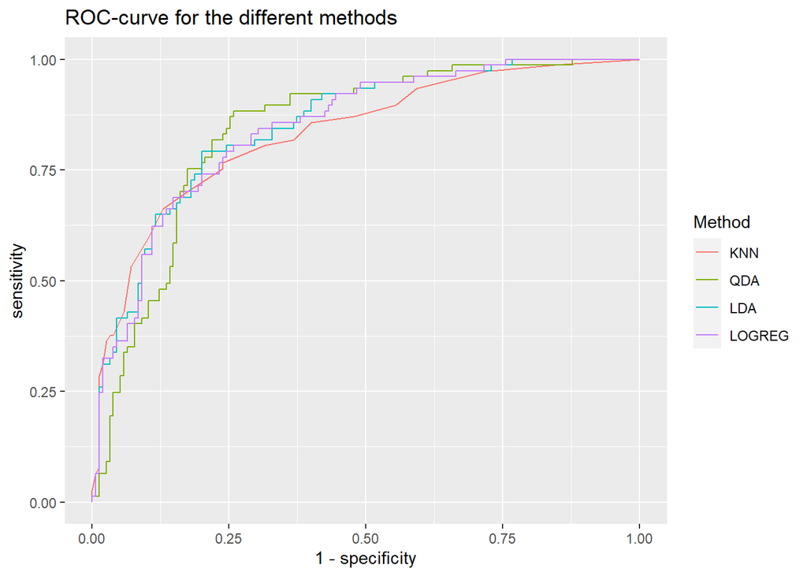

[output not shown]

```r
#KNN that returns probabilities instead of classifications
knnMod = knn(train, test , train$diabetes, k = 25, prob = T)
probKNN = ifelse(knnMod == 0, 1 - attributes(knnMod)$prob, attributes(knnMod)$prob)

#Transform the response into a factor with levels 1 and 0
response = factor(test$diabetes)

#Create roc-objects for each method
rocknn = roc(response, probKNN)
rocquad = roc(response, qda.results$posterior[,2])
roclin = roc(response,lda.results$posterior[,2])
roclog = roc(response, glm.results)

#Storing the area under the curve for the different methods
list = list(auc(rocknn), auc(rocquad), auc(roclin), auc(roclog))

#Plotting the actual curve
ggroc(data = list("KNN" = rocknn,"QDA" = rocquad, "LDA" = roclin, "LOGREG" = roclog),legacy.axes = TRUE) + ggtitle("ROC-curve for the different methods") + labs(color="Method")
```

From the plot one can see that the methods performs very similar, with some fluctuation among them. By looking at the area under the curve, one can see that KNN performs the worst while LDA and logistic regression performs the best. If the goal is to have an interpretable model, then the logistic regression model should be used as it performs well and allows for inference.